# Data Wrangling in R

Data Wrangling in R

[Download materials](https://github.com/HSL-Data/BIMS_8382_Web/blob/master/public/zips/datawrangling.zip?raw=true)

Data analysis involves a large amount of [janitorwork](http://www.nytimes.com/2014/08/18/technology/for-big-data-scientists-hurdle-to-insights-is-janitor-work.html) – munging and cleaning data to facilitate downstream data analysis. In fact, data scientists say that around [80%](https://www.infoworld.com/article/3228245/data-science/the-80-20-data-science-dilemma.html) of their time is taken up by data cleaning tasks compared to just 20% for the actual analyses.

Our goal will be to produce “tidy data” that we can then use to derive some insights. [Tidy data](https://vita.had.co.nz/papers/tidy-data.pdf) is defined as: 1. Each variable forms a column. 2. Each observation forms a row. 3. Each type of observational unit forms a table.

To transform the data into tidy data will take different steps depending on the nature of the untidyness. Hadley Wickham, who works for RStudio, says “tidy datasets are all alike but every messy dataset is messy in its own way.”

This lesson demonstrates techniques for data cleaning and manipulation using the split-apply-combine strategy. We will make use of the tidyr package to clean the data. The dplyr package will help us effectively manipulate and conditionally compute summary statistics over subsets of data, while the stringr package will help us interact with string data.

**This lesson assumes a basic familiarity with R and data frames.**

**Recommended Resources** 1. The [*R for Data Science* book](http://r4ds.had.co.nz/tibbles.html) is a fabulous resource for learning to do data science in R.

2. There are cheatsheets available on the [RStudio website](https://www.rstudio.com/resources/cheatsheets/) for **tidyr**, **dplyr**, and **stringr**, among others. They are excellent quick reference guides for what we will learn today.

### Set up data

We need to load the readr, dplyr, tidyr, stringr, and ggplot packages. All of these packages are contained in the tidyverse megapackage. Let’s load those packages now - hopefully you have already installed them.

We will also use the ggrepl and gapminder packages today.

```r
#install.packages("tidyverse")
# Load packages
library(tidyverse)
library(ggrepel)
library(gapminder)
```

The purpose of our class today is to figure out the relationship between Student-Teacher Ratio and happiness and to explore changes in happiness across countries over time. The problem is that we do not have a single dataset with all of the variables that we will need. To get this dataset, we need to combine multiple disparate datasets.

```r
# Read in original datasets
# happy : A data set from 2019 looking at happiness scores across countries, with various other measures
happy <- read_csv("happy.csv") %>% select(country, continent, Score)
# happy_2015_2018 : A data set from 2015 - 2018 looking at happiness scores across countries
happy_2015_2018 <- read_csv("happy_2015_to_2018.csv")
# STR : A data set from 2015 - 2018 looking at Student to Teacher Ratio changes over several countries
STR <- read_csv("STR.csv") %>% arrange(country, year)
# Display the data
happy
```

```
## # A tibble: 156 x 3
##    country     continent Score
##    <chr>       <chr>     <dbl>
##  1 Finland     Europe     7.77
##  2 Denmark     Europe     7.6
##  3 Norway      Europe     7.55
##  4 Iceland     Europe     7.49
##  5 Netherlands Europe     7.49
##  6 Switzerland Europe     7.48
##  7 Sweden      Europe     7.34
##  8 New Zealand Oceania    7.31
##  9 Canada      Americas   7.28
## 10 Austria     Europe     7.25
## # ... with 146 more rows
```

```r
happy_2015_2018
```

```
## # A tibble: 626 x 3
##    country      year Score
##    <chr>       <dbl> <dbl>
##  1 Finland      2018  7.63
##  2 Norway       2018  7.59
##  3 Denmark      2018  7.56
##  4 Iceland      2018  7.50
##  5 Switzerland  2018  7.49
##  6 Netherlands  2018  7.44
##  7 Canada       2018  7.33
##  8 New Zealand  2018  7.32
##  9 Sweden       2018  7.31
## 10 Australia    2018  7.27
## # ... with 616 more rows
```

```r
STR
```

```
## # A tibble: 484 x 4
##    country              continent  year   STR
##    <chr>                <chr>     <dbl> <dbl>
##  1 Afghanistan          Asia       2015  44.3
##  2 Afghanistan          Asia       2017  44.0
##  3 Africa (Northern)    <NA>       2015  21.9
##  4 Africa (Northern)    <NA>       2016  22.4
##  5 Africa (Northern)    <NA>       2017  22.9
##  6 Africa (Sub-Saharan) <NA>       2015  38.6
##  7 Africa (Sub-Saharan) <NA>       2016  38.6
##  8 Africa (Sub-Saharan) <NA>       2017  38.5
##  9 Albania              Europe     2015  18.6
## 10 Albania              Europe     2016  18.2
## # ... with 474 more rows
```

# Reshaping - pivot_wider & pivot_longer

The first problem we will tackle is reshaping the dataframe. Notice that we have several rows that seem to be encoding the same information across different years when we look at the happy_2015_2018 dataset. At times, we want the dataset to be set up like this, but to be able to combine it to our other datasets, we will need to reshape.

```r
#View(happy_2015_2018)
```

The Score column is repeated across the countries for each year. This longitudinal/panel style of dataset is considered a `long` dataset, where you have many observations and few columns/variables. This set up is nice for looking at time series or repeated measures. However, we want to turn it into a `wide` dataset, where there are more variables and fewer observations.

We will use the `pivot_wider` function to change our dataset from `long` to `wide`. Conversely the `pivot_longer` function changes a dataset from `wide` to `long`.

After the dataframe, `pivot_wider()` needs 3 other arguments. The first one is where you are getting your new variable names from. Since you will be creating several variables, R needs a way to tell how to name them. The second argument, `names_glue` provides a way to control how the variables are named with a pattern. Finally, the third argument below tells us where to get the values for the new variables.

```r
#?pivot_wider
names(happy_2015_2018)
happy_2015_2018 %>%
  pivot_wider(names_from = year, names_glue = "Score_{year}", values_from = Score)

# If we took off the names_glue argument, our variable names would just be 2015, 2016, etc.
happy_wide <- happy_2015_2018 %>%
  pivot_wider(names_from = year, names_glue = "Score_{year}", values_from = Score)
```

As mentioned earlier, `pivot_longer()` is the inverse of `pivot_wider`. We will use this a bit later, but essentially you tell R the columns that you want to gather and then the name for the new column you are creating.

```r
#?pivot_longer
happy_wide %>%
  pivot_longer(cols = starts_with("Score_"), values_to = "Score") %>%
  mutate(year = str_replace(name, "Score_", "")) %>%
  select(-name)
```

```
## # A tibble: 672 x 3
##    country Score year
##    <chr>   <dbl> <chr>
##  1 Finland  7.63 2018
##  2 Finland  7.47 2017
##  3 Finland  7.41 2016
##  4 Finland  7.41 2015
##  5 Norway   7.59 2018
##  6 Norway   7.54 2017
##  7 Norway   7.50 2016
##  8 Norway   7.52 2015
##  9 Denmark  7.56 2018
## 10 Denmark  7.52 2017
## # ... with 662 more rows
```

### Exercise

Using `STR` create a new dataset called `STR_wide` that only has one observation per country and contains all years of student teacher ratio data (STR).

```r
STR_wide <- STR %>%
    pivot_wider(names_from = year, names_glue = "STR_{year}", values_from = STR)
```

## Separate & Unite

```r
big_mac <- read_csv("big_mac.csv")
big_mac
```

One of the first problems I see is that there are multiple pieces of data encoded into the column called `country_price`. Luckily, the data are separated neatly by `::`. Let’s use the separate function from the tidyr package to create new columns from the original `country_price` column.

# Separate

```r
#?separate
#country_price has 2 pieces of information
big_mac %>%
  separate(col = country_price, into = c("country", "price"), sep = "::")
```

```r
big_mac
```

Let’s keep the change created by the `separate()` function by saving original with separate back into original

```r
big_mac_new <- big_mac %>%
  separate(col = country_price, into = c("country", "price"), sep = "::")

#Make sure to look at the variable types after a separate
big_mac_new$price <- as.numeric(big_mac_new$price)
```

If the separator was not as neat as this, you can input any [regular expression](https://en.wikipedia.org/wiki/Regular_expression) into the separator argument.

## Resources for Regular Expressions

For a nice cheatsheet for writing regular expressions in R, see a [Regex cheatsheet](http://www.cbs.dtu.dk/courses/27610/regular-expressions-cheat-sheet-v2.pdf). Jenny Bryan has created a nice website tutorial for learning to use [Regular Expressions in R](http://stat545.com/block022_regular-expression.html).

```r
new_df <- tibble(a = c("EducationSEP52", "Business2SEP43"))
new_df
```

```
## # A tibble: 2 x 1
##   a
##   <chr>
## 1 EducationSEP52
## 2 Business2SEP43
```

```r
separate(data = new_df, col = a, into = c("Field", "Age"), sep = "SEP")
```

```
## # A tibble: 2 x 2
##   Field     Age
##   <chr>     <chr>
## 1 Education 52
## 2 Business2 43
```

```r
new_df <- tibble(a = c("EducationSEP52", "BusinessIFJ43"))
new_df
```

```
## # A tibble: 2 x 1
##   a
##   <chr>
## 1 EducationSEP52
## 2 BusinessIFJ43
```

```r
separate(data = new_df, col = a, into = c("Field", "Age"), sep = "[A-Z]{3}")
```

```
## # A tibble: 2 x 2
##   Field     Age
##   <chr>     <chr>
## 1 Education 52
## 2 Business  43
```

# Unite

Unite is essentially the opposite of separate. It acts much like paste would work, where it combines two (or more) separate columns into one while separating with a specific value

```r
# Let's pretend we want to reunite the country and continent by several colons
big_mac_new %>% unite(col = new_var, c("country", "continent"), sep = ",")
```

```
## # A tibble: 1,146 x 3
##    date     new_var               price
##    <chr>    <chr>                 <dbl>
##  1 4/1/2000 Argentina,Americas     2.5
##  2 4/1/2000 Australia,Oceania      1.54
##  3 4/1/2000 Brazil,Americas        1.65
##  4 4/1/2000 Canada,Americas        1.94
##  5 4/1/2000 Switzerland,Europe     3.47
##  6 4/1/2000 Chile,Americas         2.45
##  7 4/1/2000 China,Asia             1.20
##  8 4/1/2000 Czech Republic,Europe  1.39
##  9 4/1/2000 Denmark,Europe         3.08
## 10 4/1/2000 Hungary,Europe         1.22
## # ... with 1,136 more rows
```

### Exercise

1. Use Separate to separate the a column in `new_df` into two separate columns.
2. Reunite the two columns and use a separator of your choice.

```r
new_df <- tibble(a = c("OnePiece--21", "TwoPiece--25"))
new_df
```

```
## # A tibble: 2 x 1
##   a
##   <chr>
## 1 OnePiece--21
## 2 TwoPiece--25
```

```r
#1.
n <- new_df %>% separate(col = a, into = c("var", "value"), sep = "--")
n
```

```
## # A tibble: 2 x 2
##   var      value
##   <chr>    <chr>
## 1 OnePiece 21
## 2 TwoPiece 25
```

```r
#2.
unite(n, new_var, c("var", "value"), sep = "WHATEVER")
```

```
## # A tibble: 2 x 1
##   new_var
##   <chr>
## 1 OnePieceWHATEVER21
## 2 TwoPieceWHATEVER25
```

### Merging Datasets Together

We are now going to work on merging datasets together to make one complete dataset. This isn’t always necessary, but sometimes it is helpful to have all of your data in one place. But first, a bit of prework:

```r
x <- STR_wide %>%
  head(10)

y <- happy %>%
  arrange(country) %>%
  head(10)

x
```

```
## # A tibble: 10 x 6
##    country                     continent STR_2015 STR_2017 STR_2016 STR_2018
##    <chr>                       <chr>        <dbl>    <dbl>    <dbl>    <dbl>
##  1 Afghanistan                 Asia         44.3      44.0     NA         NA
##  2 Africa (Northern)           <NA>         21.9      22.9     22.4       NA
##  3 Africa (Sub-Saharan)        <NA>         38.6      38.5     38.6       NA
##  4 Albania                     Europe       18.6      17.9     18.2       NA
##  5 Algeria                     Africa       23.8      24.2     24.2       NA
##  6 Andorra                     <NA>          9.94     10.5     10.1       NA
##  7 Angola                      <NA>         50.0      NA       NA         NA
##  8 Antigua and Barbuda         <NA>         14.3      12.1     NA         NA
##  9 Arab States                 <NA>         19.5      20.2     19.9       NA
## 10 Asia (Central and Southern) <NA>         31.8      34.1     34.5       NA
```

```r
y
```

```
## # A tibble: 10 x 3
##    country     continent Score
##    <chr>       <chr>     <dbl>
##  1 Afghanistan Asia       3.20
##  2 Albania     Europe     4.72
##  3 Algeria     Africa     5.21
##  4 Argentina   Americas   6.09
##  5 Armenia     <NA>       4.56
##  6 Australia   Oceania    7.23
##  7 Austria     Europe     7.25
##  8 Azerbaijan  <NA>       5.21
##  9 Bahrain     Asia       6.20
## 10 Bangladesh  Asia       4.46
```

There are several types of joins (merges) that we can use. The one you use depends upon your specific needs.

inner_join(): return all rows from x where there are matching values in y, and all columns from x and y. If there are multiple matches between x and y, all combination of the matches are returned.

```r
# Notice the continent.x and continent.y
inner_join(x, y, by = "country")
```

```
## # A tibble: 3 x 8
##   country     continent.x STR_2015 STR_2017 STR_2016 STR_2018 continent.y Score
##   <chr>       <chr>          <dbl>    <dbl>    <dbl>    <dbl> <chr>       <dbl>
## 1 Afghanistan Asia            44.3     44.0     NA         NA Asia         3.20
## 2 Albania     Europe          18.6     17.9     18.2       NA Europe       4.72
## 3 Algeria     Africa          23.8     24.2     24.2       NA Africa       5.21
```

left_join(): return all rows from x, and all columns from x and y. Rows in x with no match in y will have NA values in the new columns. If there are multiple matches between x and y, all combinations of the matches are returned.

```r
left_join(x, y, by = "country")
```

```
## # A tibble: 10 x 8
##    country     continent.x STR_2015 STR_2017 STR_2016 STR_2018 continent.y Score
##    <chr>       <chr>          <dbl>    <dbl>    <dbl>    <dbl> <chr>       <dbl>
##  1 Afghanistan Asia           44.3      44.0     NA         NA Asia         3.20
##  2 Africa (No~ <NA>           21.9      22.9     22.4       NA <NA>        NA
##  3 Africa (Su~ <NA>           38.6      38.5     38.6       NA <NA>        NA
##  4 Albania     Europe         18.6      17.9     18.2       NA Europe       4.72
##  5 Algeria     Africa         23.8      24.2     24.2       NA Africa       5.21
##  6 Andorra     <NA>            9.94     10.5     10.1       NA <NA>        NA
##  7 Angola      <NA>           50.0      NA       NA         NA <NA>        NA
##  8 Antigua an~ <NA>           14.3      12.1     NA         NA <NA>        NA
##  9 Arab States <NA>           19.5      20.2     19.9       NA <NA>        NA
## 10 Asia (Cent~ <NA>           31.8      34.1     34.5       NA <NA>        NA
```

right_join(): return all rows from y, and all columns from x and y. Rows in y with no match in x will have NA values in the new columns. If there are multiple matches between x and y, all combinations of the matches are returned.

```r
right_join(x, y, by = "country")
```

```
## # A tibble: 10 x 8
##    country     continent.x STR_2015 STR_2017 STR_2016 STR_2018 continent.y Score
##    <chr>       <chr>          <dbl>    <dbl>    <dbl>    <dbl> <chr>       <dbl>
##  1 Afghanistan Asia            44.3     44.0     NA         NA Asia         3.20
##  2 Albania     Europe          18.6     17.9     18.2       NA Europe       4.72
##  3 Algeria     Africa          23.8     24.2     24.2       NA Africa       5.21
##  4 Argentina   <NA>            NA       NA       NA         NA Americas     6.09
##  5 Armenia     <NA>            NA       NA       NA         NA <NA>         4.56
##  6 Australia   <NA>            NA       NA       NA         NA Oceania      7.23
##  7 Austria     <NA>            NA       NA       NA         NA Europe       7.25
##  8 Azerbaijan  <NA>            NA       NA       NA         NA <NA>         5.21
##  9 Bahrain     <NA>            NA       NA       NA         NA Asia         6.20
## 10 Bangladesh  <NA>            NA       NA       NA         NA Asia         4.46
```

full_join(): return all rows and all columns from both x and y. Where there are not matching values, returns NA for the one missing.

```r
full_join(x, y, by = "country")
```

```
## # A tibble: 17 x 8
##    country     continent.x STR_2015 STR_2017 STR_2016 STR_2018 continent.y Score
##    <chr>       <chr>          <dbl>    <dbl>    <dbl>    <dbl> <chr>       <dbl>
##  1 Afghanistan Asia           44.3      44.0     NA         NA Asia         3.20
##  2 Africa (No~ <NA>           21.9      22.9     22.4       NA <NA>        NA
##  3 Africa (Su~ <NA>           38.6      38.5     38.6       NA <NA>        NA
##  4 Albania     Europe         18.6      17.9     18.2       NA Europe       4.72
##  5 Algeria     Africa         23.8      24.2     24.2       NA Africa       5.21
##  6 Andorra     <NA>            9.94     10.5     10.1       NA <NA>        NA
##  7 Angola      <NA>           50.0      NA       NA         NA <NA>        NA
##  8 Antigua an~ <NA>           14.3      12.1     NA         NA <NA>        NA
##  9 Arab States <NA>           19.5      20.2     19.9       NA <NA>        NA
## 10 Asia (Cent~ <NA>           31.8      34.1     34.5       NA <NA>        NA
## 11 Argentina   <NA>           NA        NA       NA         NA Americas     6.09
## 12 Armenia     <NA>           NA        NA       NA         NA <NA>         4.56
## 13 Australia   <NA>           NA        NA       NA         NA Oceania      7.23
## 14 Austria     <NA>           NA        NA       NA         NA Europe       7.25
## 15 Azerbaijan  <NA>           NA        NA       NA         NA <NA>         5.21
## 16 Bahrain     <NA>           NA        NA       NA         NA Asia         6.20
## 17 Bangladesh  <NA>           NA        NA       NA         NA Asia         4.46
```

So now, let us try and merge together our datasets.

Let’s try an inner join

```r
#Notice that each of the datasets has a unit of observation as country. The original happy_2015_2018 dataset had a country, year level of observation which would have been more difficult to merge onto.

#inner join happy with happy_wide
#using the c() command here, although it is only one variable I am using to join.
inner_join(happy, happy_wide, by = c("country"))
#154 matches

#However, we still want to keep all the stuff from the happy dataset
happy_over_years <- left_join(happy, happy_wide, by = "country")
#156 matches

#A right_join would keep things in the right dataset.
right_join(happy, happy_wide, by = "country")
#168 matches

#Now I want to join together the data from our happy_over_years to our STR dataset.
STR_wide

inner_join(happy_over_years, STR_wide, by = c("country"))
#I really only want the countries that have both STR data and happiness data.
happy_STR <- inner_join(happy_over_years, STR_wide, by = c("country"))
View(happy_STR)
```

# Clean Up

Oftentimes after combining/merging datasets together, clean up is necessary

```r
happy_STR <- happy_STR %>%
  rename(Score_2019 = Score)

# Checking to see the continent variables
happy_STR %>% select(continent.x, continent.y) %>% print(n = Inf)
```

```
## # A tibble: 111 x 2
##     continent.x continent.y
##     <chr>       <chr>
##   1 Europe      Europe
##   2 Europe      Europe
##   3 Europe      Europe
##   4 Europe      Europe
##   5 Europe      Europe
##   6 Europe      Europe
##   7 Oceania     Oceania
##   8 Europe      Europe
##   9 Americas    Americas
##  10 Asia        Asia
##  11 <NA>        <NA>
##  12 Europe      Europe
```

[output cut: 99 more lines]

```r
# Since they are duplicates we can drop one if we like
happy_STR <- happy_STR %>%
  select(-continent.y) %>%
  rename(continent = continent.x)
```

## Visualizing our new dataset

Let’s visually look at this data using a new geom type, `geom_line`. The line graph works well on longitudinal/panel data. So we first need to get scores over the years.

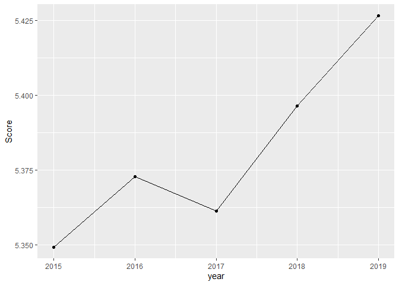

```r
#Let's first set up out dataset so that it is long (Undoing a lot of work we've done so far)
happy_prep <- happy_STR %>%
pivot_longer(cols = starts_with("Sco"), values_to = "Score") %>%
  mutate(year = as.numeric(str_replace(name, "Score_", ""))) %>%
  select(Score, country, continent, year)

# We will then look at Happiness Scores over time
happy_prep %>%
  group_by(year) %>%
  summarize(Score = mean(Score, na.rm = TRUE)) %>%
  ggplot(aes(year, Score)) +
  geom_point() + geom_line()
```

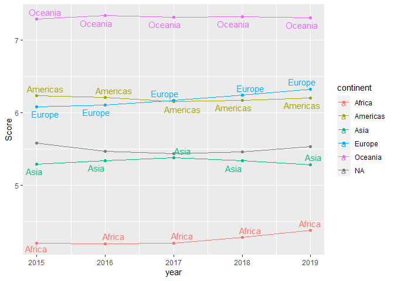

```r
happy_prep   %>%
  group_by(year, continent) %>%
  summarize(Score = mean(Score, na.rm = TRUE)) %>%
  ggplot(aes(year, Score, color = continent)) +
  geom_point() +
  geom_line() +
  geom_text_repel(aes(label = continent))
```

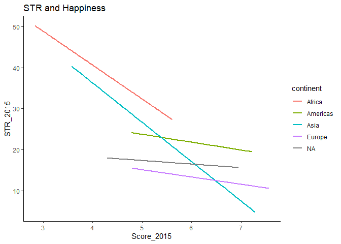

```r
happy_STR %>%
  ggplot(aes(Score_2015, STR_2015, color = continent))  +
  geom_smooth(method = "lm", se = FALSE) +
  theme_classic() +
  ggtitle("STR and Happiness")
```

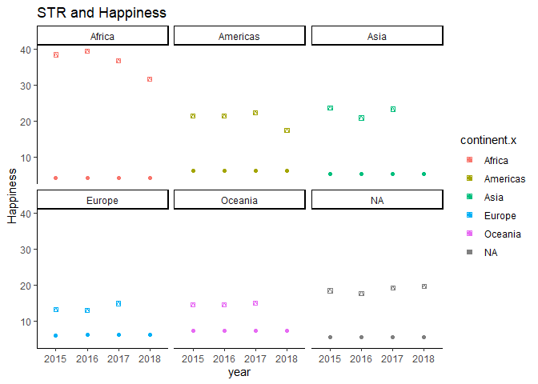

```r
happy_STR_scores <- happy_STR %>%
 pivot_longer(cols = starts_with("Score_"), values_to = "Score") %>%
  mutate(year = str_replace(name, "Score_", "")) %>%
  select(country, continent, year, Score)

happy_STR_STRs <- happy_STR %>%
  pivot_longer(cols = starts_with("STR_"), values_to = "STR") %>%
  mutate(year = str_replace(name, "STR_", "")) %>%
  select(country, continent, year, STR)

happy_STR_combined <- inner_join(happy_STR_scores, happy_STR_STRs, by = c("country", "year"))

happy_STR_combined %>%
  group_by(year, continent.x) %>%
  summarize(Happiness = mean(Score, na.rm = TRUE),
            STR = mean(STR, na.rm = TRUE)) %>%
  ggplot(aes(x = year, y = Happiness, color = continent.x)) +
  geom_point()+
  geom_point(aes(y = STR), shape = 14) +
  theme_classic()+ facet_wrap(~continent.x) +
  ggtitle("STR and Happiness")
```

So we found that their may be a correlation between happiness and STR.

# Longitudinal Data

These are just some extensions to what we were looking at before.

```
## geom_path: Each group consists of only one observation. Do you need to adjust
## the group aesthetic?
```

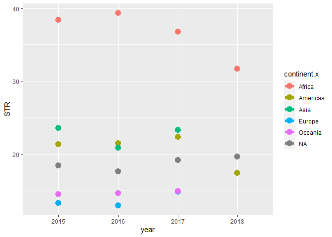

```r
p <- happy_STR_combined %>%
  group_by(year, continent.x) %>%
  summarize(STR = mean(STR, na.rm = TRUE)) %>%
  ggplot(aes(year, STR, color = continent.x)) +
  geom_line(size = 2) +
  geom_point(size = 4)
p
```

If you want to create a more aesthetically appealing graph, you can remove the legend and add labels to your graphs. Adding labels to our graphs involves the use of a function from the `ggrepel` package.

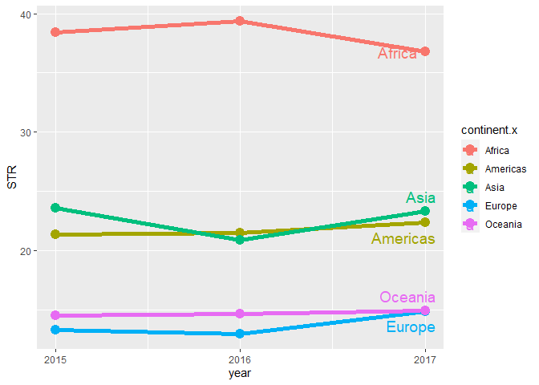

```r
happy_STR_combined$year <- as.numeric(happy_STR_combined$year)
 happy_STR_combined %>%
  filter(year < 2018) %>%
  drop_na(continent.x) %>%
  group_by(year, continent.x) %>%
  summarize(STR = mean(STR, na.rm = TRUE)) %>%
  mutate(label = if_else(year == 2017, as.character(continent.x), NA_character_)) %>% ungroup() %>%
  ggplot(aes(year, STR, color = continent.x, group = continent.x)) +
  geom_line(size = 2) +
  geom_point(size = 4) +
        scale_x_continuous(breaks = seq(from = 2015, to = 2017, by = 1)) +
  geom_label_repel(aes(label = label, group = continent.x), nudge_x = 1, na.rm = TRUE, label.size = NA, fill = NA, size = 5)
```

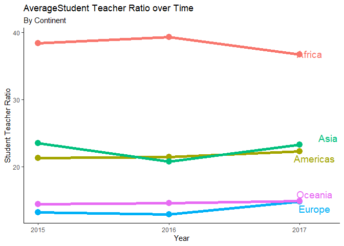

```r
# Adding some extra aesthetics
 happy_STR_combined %>%
  filter(year < 2018) %>%
  drop_na(continent.x) %>%
  group_by(year, continent.x) %>%
  summarize(STR = mean(STR, na.rm = TRUE)) %>%
  mutate(label = if_else(year == 2017, as.character(continent.x), NA_character_))  %>%
  ggplot(aes(year, STR, color = continent.x, group = continent.x)) +
  geom_line(size = 2) +
  geom_point(size = 4) +
     scale_x_continuous(breaks = seq(from = 2015, to = 2017, by = 1)) +
geom_text_repel(aes(label = label, x = year + .2, color = continent.x), size = 5) +
  guides(color = FALSE) +
  theme_classic() +
  labs(x = "Year", y = "Student Teacher Ratio", title = "AverageStudent Teacher Ratio over Time", subtitle = "By Continent")
```

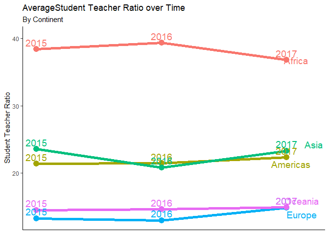

```r
# Data labels for each year.
 happy_STR_combined %>%
  filter(year < 2018) %>%
  drop_na(continent.x) %>%
  group_by(year, continent.x) %>%
  summarize(STR = mean(STR, na.rm = TRUE)) %>%
  mutate(label = if_else(year == 2017, as.character(continent.x), NA_character_))  %>%
  ggplot(aes(year, STR, color = continent.x, group = continent.x)) +
  geom_line(size = 2) +
  geom_point(size = 4) +
     scale_x_continuous(breaks = seq(from = 2015, to = 2017, by = 1)) +
geom_text_repel(aes(label = label, x = year + .2, color = continent.x), size = 5) +
  geom_text(aes(label = year,  color = continent.x), size = 5, nudge_y = 1) +
  guides(color = FALSE) +
  theme_classic() +   theme(axis.title.x = element_blank(), axis.ticks.x = element_blank(), axis.text.x = element_blank()) +
  labs(x = "Year", y = "Student Teacher Ratio", title = "AverageStudent Teacher Ratio over Time", subtitle = "By Continent")
```